# 105-2 資料科學程式設計_作業4

氣候所碩一 R05247008 何威融

2017/5/18

### 二、資料說明

- 用電資料來源：台大校園即時電力監測系統（http://140.112.166.97/power/index.aspx
- 理學院單位：包含7個系、5個所、7個研究中心，本次以大學部「系」建物為單位，分別是數學系（數學館、新數學研究中心）、化學系（化學館、積學館）、物理系（凝態館）、心理系（心理系南、北館）、地質系（地質系館）、地理系（地理系館）、大氣系（A、B棟及人工氣候室）。
- 用電資料處理：因為每個系的空間分佈不同，而建物中又同時有不同分配及配電方式（配電站、獨立電表），補充說明資料選擇及修正如下。
- 同個建物不同電表合併計算：物理系（凝態館及其停車場）
- 不同建築物但共用電表：大氣系（A、B棟），實驗用的人工氣候室則特別分開
- 天氣資料來源：TTFRI颱風洪水研究中心資料庫
- 天氣資料取用說明：溫度資料（當日最高溫及最低溫）、相對濕度（RH值）

### 三、建物用電資料概覽（2016/7）

```r
rawdata <- readxl::read_excel ("e.xlsx")

lastdayId = length(rawdata$day)
firstday = rawdata$day[1]
lastday = rawdata$day[lastdayId]
n = lastday - firstday + 1

library(plotly)
require(ggplot2)

allType = names(rawdata)

# NerTbale is as follows:
# day, kwh, dept
# a, 407.39, math.

deptId = c(2:8)
newTable = data.frame()
for( nid in c(1:n) )
{
  day = as.matrix(rep(rawdata$day[nid], length(rawdata[nid,deptId])))
  kwh = as.matrix(as.numeric(rawdata[nid,deptId]))
  dept = as.matrix(as.character(allType[deptId]))
  temp = cbind(day, kwh, dept)
  newTable = rbind(newTable, temp)
}
names(newTable) = c('day', 'kwh', 'dept')
library(reshape2)
t.rawdata <- melt(rawdata,id.vars = "day")
p <- plot_ly(t.rawdata, x=~day, y=~value,color=~variable) %>%
  add_lines() %>%
  layout(title = "理院建物用電統計（2016/7）",
         xaxis = list(title = "day"),
         yaxis = list(title = "kwh") )
p
```

[interactive chart not shown]

```r
htmlwidgets::saveWidget(p, "index.html")
## 統計特徵描述
summary(rawdata)
```

```
##       day           數學館         新數中心         化學館
##  Min.   : 1.0   Min.   :313.4   Min.   :175.3   Min.   :10277
##  1st Qu.: 8.5   1st Qu.:465.7   1st Qu.:262.7   1st Qu.:11868
##  Median :16.0   Median :637.7   Median :414.6   Median :13069
##  Mean   :16.0   Mean   :623.5   Mean   :371.5   Mean   :12628
##  3rd Qu.:23.5   3rd Qu.:772.0   3rd Qu.:461.1   3rd Qu.:13493
##  Max.   :31.0   Max.   :854.3   Max.   :555.1   Max.   :14316
##      積學館          凝態館        心理系南館      心理系北館
##  Min.   : 5924   Min.   :16760   Min.   :203.2   Min.   :1512
##  1st Qu.: 8472   1st Qu.:19398   1st Qu.:262.0   1st Qu.:1943
##  Median : 9865   Median :20170   Median :417.7   Median :2149
##  Mean   : 9159   Mean   :20433   Mean   :393.2   Mean   :2104
##  3rd Qu.:10271   3rd Qu.:21886   3rd Qu.:451.1   3rd Qu.:2267
##  Max.   :10574   Max.   :22725   Max.   :702.1   Max.   :2493
##     地質系館       地理系館        大氣系AB館     人工氣候室
##  Min.   :4483   Min.   : 592.4   Min.   :1166   Min.   :3599
##  1st Qu.:6063   1st Qu.: 728.2   1st Qu.:1193   1st Qu.:3917
##  Median :6611   Median :1249.5   Median :1215   Median :4024
##  Mean   :6403   Mean   :1092.8   Mean   :1214   Mean   :4055
##  3rd Qu.:6893   3rd Qu.:1354.0   3rd Qu.:1238   3rd Qu.:4187
##  Max.   :7860   Max.   :1527.1   Max.   :1257   Max.   :4630
```

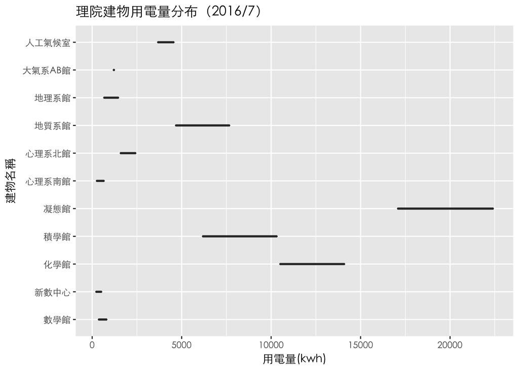

```r
## 理院建物用電量分佈
ggplot(data = t.rawdata, aes(x = value , y = variable)) +
  geom_boxplot () +
  labs( x = "用電量(kwh)", y = "建物名稱", title = "理院建物用電量分布（2016/7）") +
  theme_grey (base_family = "STXihei")
```

### 四、變量分析

#### （一）日均溫

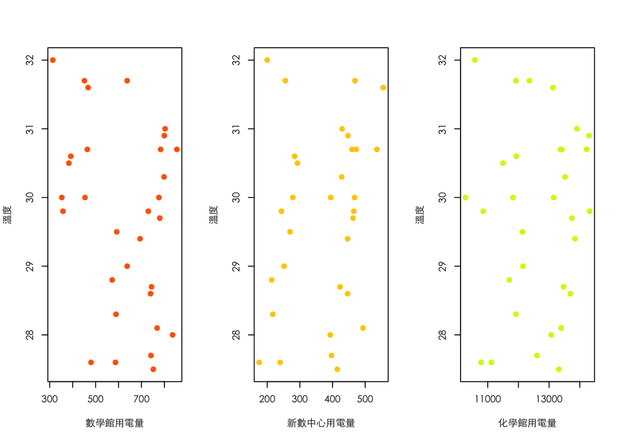

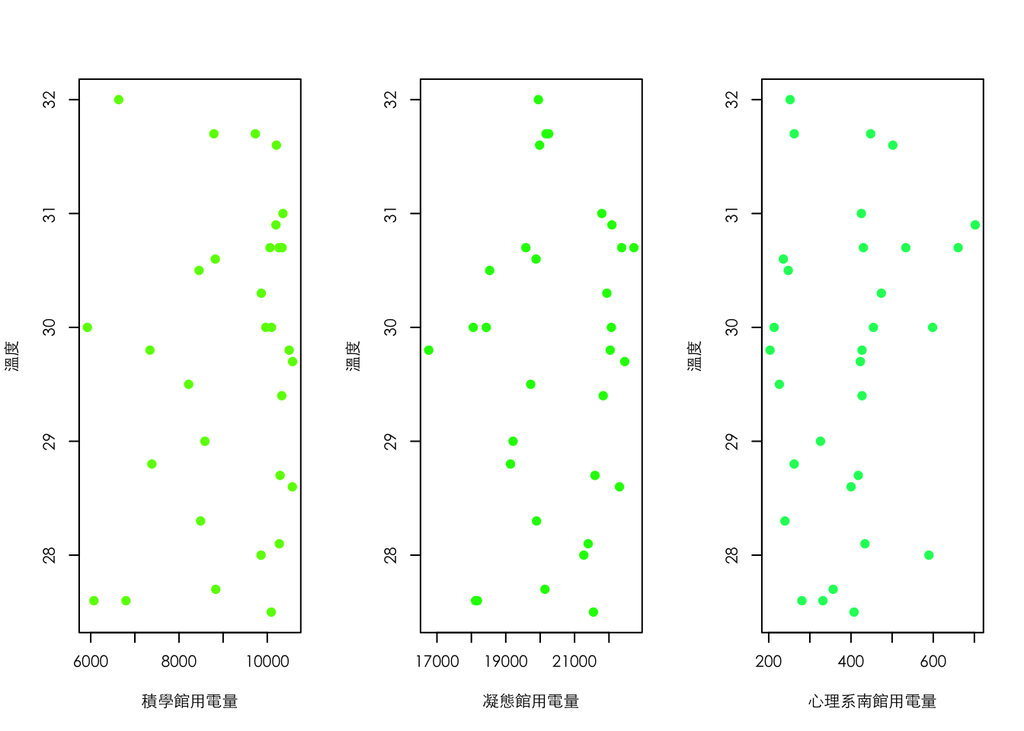

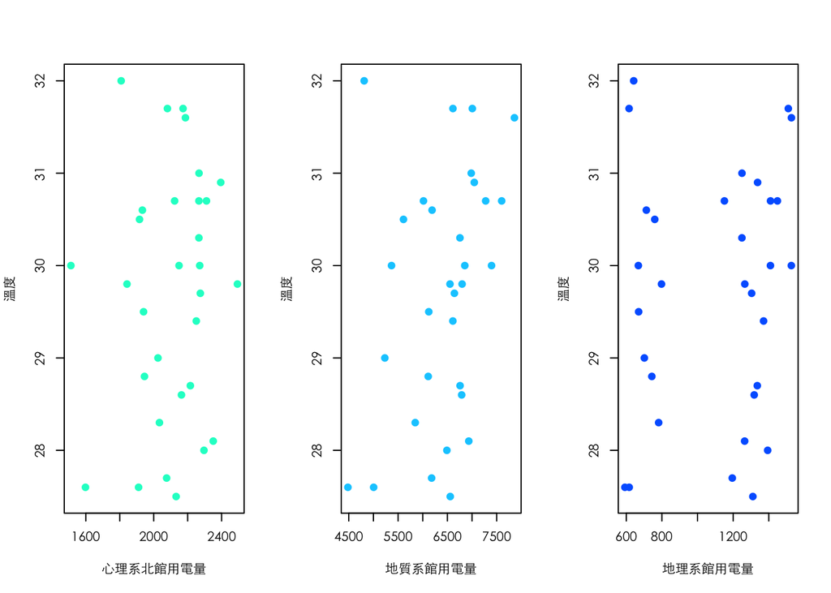

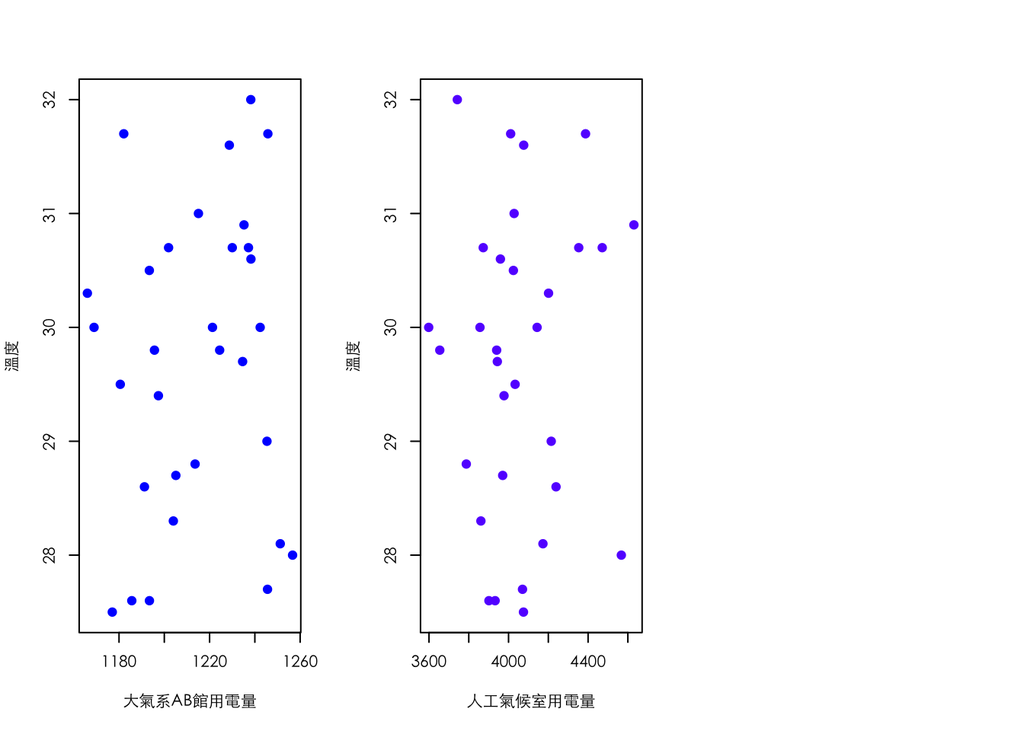

```r
rawdata <- readxl::read_excel ("e.xlsx")
rawT <- readxl::read_excel ("T.xlsx")
require(ggplot2)


btn <- c("day","數學館","新數中心","化學館","積學館","凝態館","心理系南館","心理系北館","地質系館","地理系館","大氣系AB館","人工氣候室")

colnames(rawdata) <- 1:dim(rawdata)[2]
lin <- function(x) {
  lm( rawT[[2]] ~ x)
}
lnco <- apply(rawdata[2:12], 2, lin)
bname <- paste0(btn ,rep("用電量",11))
layout( matrix( 1:12 , 1, 3, byrow = T ))
par(family="STXihei")

for(i in seq(2, 12) ){
  plot(rawdata[[i]], rawT[[2]], pch = 16, cex = 1.3, col = rainbow(15)[i],
  xlab = bname[i], ylab = "溫度")
  abline(lnco[i])
}
```

#### （二）相對濕度

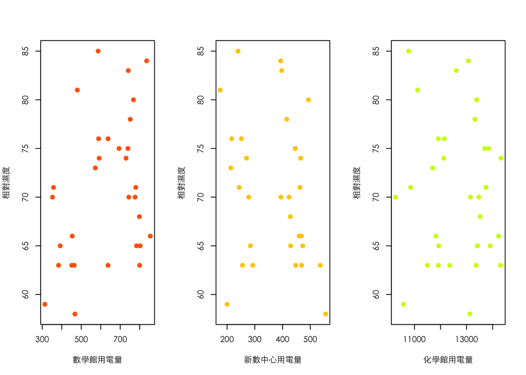

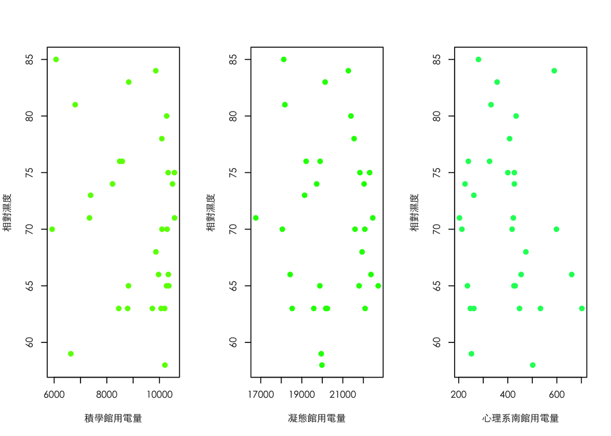

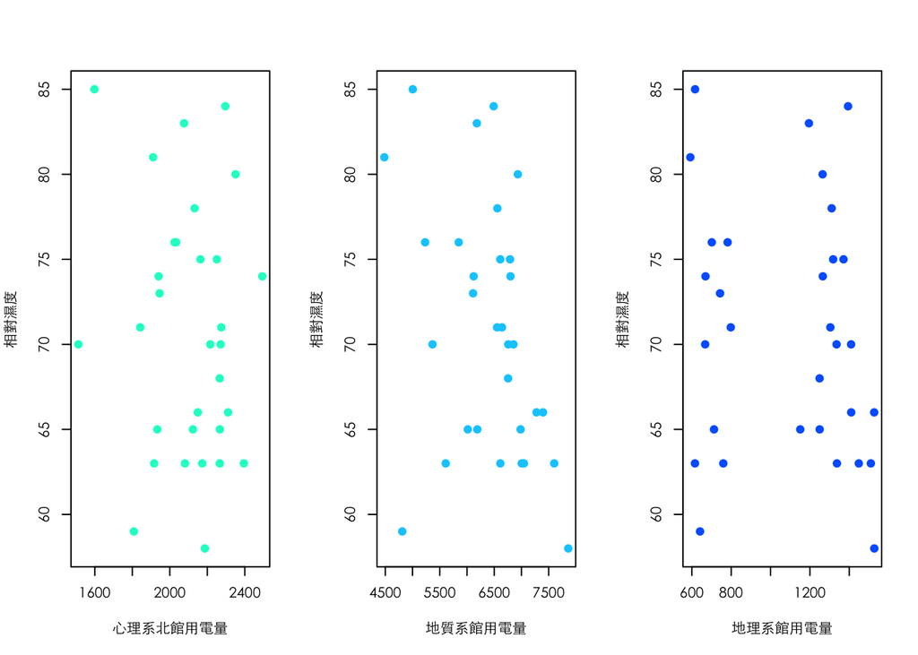

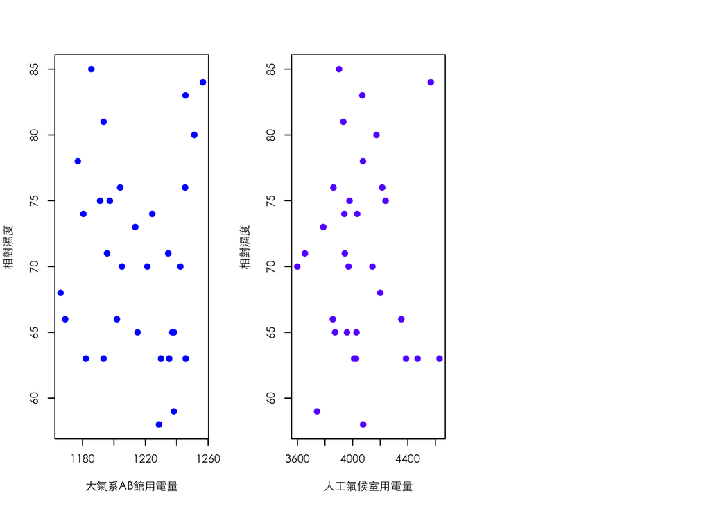

```r
rawdata <- readxl::read_excel ("e.xlsx")
rawT <- readxl::read_excel ("T.xlsx")
require(ggplot2)


btn <- c("day","數學館","新數中心","化學館","積學館","凝態館","心理系南館","心理系北館","地質系館","地理系館","大氣系AB館","人工氣候室")

colnames(rawdata) <- 1:dim(rawdata)[2]
lin <- function(x) {
  lm( rawT[[5]] ~ x)
}
lnco <- apply(rawdata[2:12], 2, lin)
bname <- paste0(btn ,rep("用電量",11))
layout( matrix( 1:12 , 1, 3, byrow = T ))
par(family="STXihei")

for(i in seq(2, 12) ){
  plot(rawdata[[i]], rawT[[5]], pch = 16, cex = 1.3, col = rainbow(15)[i],
  xlab = bname[i], ylab = "相對濕度")
  abline(lnco[i])
}
```

### 五、資料特徵小結

可以從圖表中發現理學院用電量前五名的建物為：凝態館>化學館>積學館>地質系館>人工氣候室。而這五棟建物同時也是跨度最廣的前五棟。在和溫度做完回歸分析之後，發現因為資料量太少（只有31天），所以其實看不太出來相關性。之後可以搜集整理年度資料再做一次雙變數分析，或許會有新的發現。

### 六、原始資料表格

#### （一）、建物用電資料表（2016/7）

```r
knitr::kable (rawdata)
```

| 1 | 2 | 3 | 4 | 5 | 6 | 7 | 8 | 9 | 10 | 11 | 12 |
| --- | --- | --- | --- | --- | --- | --- | --- | --- | --- | --- | --- |
| 1 | 798.41 | 427.95 | 13517.58 | 9864.93 | 21938.89 | 473.75 | 2266.25 | 6754.87 | 1249.19 | 1166.02 | 4201.15 |
| 2 | 588.96 | 216.90 | 11916.47 | 8489.90 | 19894.27 | 239.37 | 2033.76 | 5847.76 | 781.85 | 1203.99 | 3860.99 |
| 3 | 572.23 | 213.42 | 11701.43 | 7385.22 | 19138.10 | 261.91 | 1945.65 | 6111.39 | 743.59 | 1213.60 | 3787.54 |
| 4 | 776.00 | 394.30 | 13149.52 | 10095.50 | 22069.99 | 598.40 | 2271.11 | 6853.10 | 1409.27 | 1242.35 | 4143.55 |
| 5 | 799.57 | 447.27 | 14297.61 | 10196.14 | 22084.98 | 702.08 | 2394.93 | 7045.76 | 1337.20 | 1235.21 | 4630.40 |
| 6 | 854.29 | 459.45 | 14219.62 | 10337.79 | 22370.30 | 660.57 | 2310.86 | 7276.50 | 1409.80 | 1201.89 | 4353.05 |
| 7 | 835.57 | 392.96 | 13069.21 | 9859.79 | 21268.85 | 589.54 | 2296.19 | 6489.71 | 1393.69 | 1256.66 | 4567.17 |
| 8 | 480.07 | 175.26 | 11120.21 | 6798.68 | 18176.79 | 331.81 | 1910.94 | 4482.54 | 592.39 | 1193.43 | 3932.49 |
| 9 | 637.68 | 251.57 | 12148.87 | 8586.96 | 19211.92 | 325.82 | 2025.13 | 5231.53 | 701.55 | 1245.35 | 4214.68 |
| 10 | 586.62 | 239.44 | 10784.10 | 6072.68 | 18121.28 | 280.68 | 1598.00 | 5004.60 | 616.53 | 1185.64 | 3901.41 |
| 11 | 741.50 | 396.85 | 12601.91 | 8832.96 | 20138.79 | 356.63 | 2076.12 | 6180.56 | 1195.09 | 1245.59 | 4070.22 |
| 12 | 768.07 | 493.21 | 13388.94 | 10273.77 | 21395.79 | 433.94 | 2350.69 | 6933.88 | 1264.47 | 1251.22 | 4172.97 |
| 13 | 693.81 | 445.90 | 13842.75 | 10328.58 | 21832.20 | 426.87 | 2250.87 | 6611.05 | 1370.72 | 1197.40 | 3977.29 |
| 14 | 729.88 | 465.17 | 14316.23 | 10496.16 | 22036.37 | 426.88 | 2493.25 | 6798.71 | 1265.35 | 1224.45 | 3940.22 |
| 15 | 802.84 | 429.21 | 13904.17 | 10354.73 | 21792.82 | 425.25 | 2267.00 | 6983.94 | 1249.53 | 1215.08 | 4028.04 |
| 16 | 637.46 | 255.51 | 12355.68 | 8790.81 | 20246.76 | 262.00 | 2080.88 | 6612.63 | 615.93 | 1182.10 | 4010.66 |
| 17 | 591.85 | 269.82 | 12128.15 | 8218.89 | 19724.81 | 225.93 | 1940.24 | 6122.69 | 669.46 | 1180.56 | 4033.04 |
| 18 | 751.50 | 414.60 | 13315.38 | 10091.35 | 21548.44 | 407.50 | 2132.05 | 6558.16 | 1310.51 | 1177.02 | 4075.06 |
| 19 | 744.03 | 423.22 | 13468.51 | 10290.56 | 21593.80 | 417.69 | 2215.94 | 6757.22 | 1335.49 | 1205.10 | 3970.58 |
| 20 | 739.59 | 446.02 | 13689.29 | 10569.20 | 22304.84 | 400.25 | 2163.54 | 6789.86 | 1318.09 | 1191.23 | 4238.85 |
| 21 | 779.75 | 462.74 | 13742.09 | 10573.74 | 22457.32 | 422.69 | 2274.72 | 6642.34 | 1303.86 | 1234.59 | 3943.61 |
| 22 | 783.51 | 472.40 | 13414.46 | 10267.76 | 22724.70 | 430.19 | 2123.27 | 6014.98 | 1150.86 | 1237.18 | 3872.71 |
| 23 | 391.84 | 283.90 | 11929.98 | 8822.74 | 19880.37 | 235.62 | 1933.35 | 6189.49 | 712.75 | 1238.27 | 3959.13 |
| 24 | 357.75 | 243.39 | 10852.23 | 7342.75 | 16760.08 | 203.21 | 1842.66 | 6552.85 | 797.80 | 1195.65 | 3654.27 |
| 25 | 453.52 | 467.51 | 11820.41 | 9966.84 | 18433.44 | 454.50 | 2149.19 | 7395.65 | 1526.50 | 1168.97 | 3856.41 |
| 26 | 463.92 | 535.76 | 13368.89 | 10062.89 | 19584.01 | 533.25 | 2266.37 | 7601.13 | 1448.44 | 1230.03 | 4471.13 |
| 27 | 467.43 | 555.11 | 13123.09 | 10207.21 | 19983.46 | 501.72 | 2186.82 | 7859.82 | 1527.07 | 1228.72 | 4076.29 |
| 28 | 451.18 | 468.53 | 11915.58 | 9731.07 | 20170.34 | 447.77 | 2172.93 | 7005.72 | 1509.63 | 1245.75 | 4387.18 |
| 29 | 313.42 | 199.84 | 10579.33 | 6634.04 | 19947.41 | 252.02 | 1808.36 | 4812.14 | 641.66 | 1238.20 | 3742.39 |
| 30 | 383.49 | 292.47 | 11498.55 | 8454.55 | 18532.27 | 247.47 | 1916.42 | 5609.48 | 759.91 | 1193.39 | 4024.32 |
| 31 | 352.56 | 278.29 | 10277.04 | 5924.17 | 18054.53 | 213.18 | 1512.22 | 5367.25 | 667.82 | 1221.29 | 3598.56 |

#### （二）、天氣原始資料表（2016/7）

```r
knitr::kable (rawT)
```

| day | T | T Max | T Min | RH |
| --- | --- | --- | --- | --- |
| 1 | 30.3 | 36.5 | 25.9 | 68 |
| 2 | 28.3 | 35.7 | 23.9 | 76 |
| 3 | 28.8 | 36.7 | 24.5 | 73 |
| 4 | 30.0 | 35.9 | 25.6 | 70 |
| 5 | 30.9 | 35.4 | 26.4 | 63 |
| 6 | 30.7 | 34.3 | 27.5 | 66 |
| 7 | 28.0 | 31.8 | 26.0 | 84 |
| 8 | 27.6 | 29.7 | 25.5 | 81 |
| 9 | 29.0 | 34.4 | 26.2 | 76 |
| 10 | 27.6 | 34.9 | 25.0 | 85 |
| 11 | 27.7 | 35.4 | 25.2 | 83 |
| 12 | 28.1 | 35.4 | 25.1 | 80 |
| 13 | 29.4 | 35.2 | 25.4 | 75 |
| 14 | 29.8 | 35.2 | 25.9 | 74 |
| 15 | 31.0 | 36.3 | 25.7 | 65 |
| 16 | 31.7 | 37.3 | 26.4 | 63 |
| 17 | 29.5 | 37.0 | 25.6 | 74 |
| 18 | 27.5 | 36.8 | 23.9 | 78 |
| 19 | 28.7 | 35.3 | 24.7 | 70 |
| 20 | 28.6 | 35.7 | 25.1 | 75 |
| 21 | 29.7 | 34.8 | 24.9 | 71 |
| 22 | 30.7 | 36.9 | 25.7 | 65 |
| 23 | 30.6 | 36.3 | 25.9 | 65 |
| 24 | 29.8 | 36.0 | 27.0 | 71 |
| 25 | 30.0 | 34.9 | 26.2 | 66 |
| 26 | 30.7 | 35.5 | 26.6 | 63 |
| 27 | 31.6 | 38.5 | 25.8 | 58 |
| 28 | 31.7 | 39.2 | 26.6 | 63 |
| 29 | 32.0 | 37.4 | 27.6 | 59 |
| 30 | 30.5 | 35.3 | 26.4 | 63 |
| 31 | 30.0 | 36.0 | 27.0 | 70 |